# Real Estate Data Visualization and Analysis

Pantea Kiaei

## Motivation

In this project, I analyzed a data set about the price per area unit of real estate in the Sindian region in New Taipei city. The goal is to make the price of real estate predictable based on its location and some extra information described in the data section. Furthermore, I made a Shiny application with the following functionalities: 1. An interactive map showing the price per unit for the real estate in the data set. The users can select the price range that they want to see to filter the available data. Also, the price of the real estate is shown by hovering over their location. The circles on the map showing the real estate locations are correlated in size with the unit price of the real estate. 2. An interactive scatter plot in which the user decides the variables to show on the x and y axes. 3. A clustering tab that clusters the real estates based on their x and y coordinates and the number of clusters can be modified by the user. 4. A linear regression tab in which the user can choose the independent variable and the regression model (between the options of linear regression and logarithmic regression). The app reports the $R^2$ measure of the chosen regression model between the price per unit of the real estate and the chosen independent variable. 5. A table showing the used data set in which the user can also look for specific data by using the search box.

## Data

The chosen data set has 414 samples of real estate information. Each sample contains the following information about the real estate: Inputs: X1 = the transaction date (for example, 2013.250=2013 March, 2013.500=2013 June, etc.) X2 = the house age (unit: year) X3 = the distance to the nearest MRT station (unit: meter) X4 = the number of convenience stores in walking distance (integer) X5 = the geographic coordinate, latitude. (unit: degree) X6 = the geographic coordinate, longitude. (unit: degree) Output: Y = house price of unit area (10000 New Taiwan Dollar/Ping, where Ping is a local unit, 1 Ping = 3.3 meter squared)

## App usage

### The Map tab

1. The circles on the map are proportional in size to the unit price of the real estate.
2. By hovering on the circles on the map, you can see the unit price.
3. By changing the price range in the slide bar, you can set the map to only show the real estate within the selected price range.

### The Scatter Plots tab

For a given variable on the x axis and a given variable on the y axis, the scatter plot will be shown.

### The Clusters tab

1. The data is clustered based on the longitude and latitude values.
2. By setting the number of clusters, you can see the k-means result for the chosen number of clusters.

### The Regression tab

1. The regression model can be chosen. The supported options are Linear and Logarithmic.
2. The independent variable (among the inputs) can be chosen.
3. The output is the $R^2$ value of the chosen regression.

### The Data tab

1. You can read and search in the data used in this project.
2. The link to access the origial data from UCI is provided.

## Load libraries:

```r
library(magrittr)
library(rvest)
```

```r
library(readxl)
library(maps)
library(ggplot2)
library(cluster)
library(ggvis)
library(dplyr)
library(shiny)
library(ggiraph)
library(RColorBrewer)
library(plsdepot)
library(visreg)
library(caret)
library(leaflet)
library(shinythemes)
library(DT)
library(SpatialEpi)
```

## Choosing and cleaning the dataset

### Quality evaluation of data set

I calculate the min, max, mean, and standard deviation of the independent variables in the data set to evaluate the quality of the dataset

```r
summaryDataset <- cbind(min(realEstate$MRTDist),max(realEstate$MRTDist),mean(realEstate$MRTDist),sd(realEstate$MRTDist))
summaryDataset <- rbind(summaryDataset,cbind(min(realEstate$numStores),max(realEstate$numStores),mean(realEstate$numStores),sd(realEstate$numStores)))
summaryDataset <- rbind(summaryDataset,cbind(min(realEstate$age),max(realEstate$age),mean(realEstate$age),sd(realEstate$age)))
summaryDataset <- rbind(summaryDataset,cbind(min(realEstate$TXDate),max(realEstate$TXDate),mean(realEstate$TXDate),sd(realEstate$TXDate)))
colnames(summaryDataset) <- cbind("Min", "Max", "Mean", "Standard deviation")
rownames(summaryDataset) <- cbind("Distance to the nearest MRT station (meter)", "Number of the convenience store in the living circle on foot", "House age (year)", "Transaction date (A.D.)")

summaryDataset
```

```
##                                                                     Min
## Distance to the nearest MRT station (meter)                    23.38284
## Number of the convenience store in the living circle on foot    0.00000
## House age (year)                                                0.00000
## Transaction date (A.D.)                                      2012.66667
##                                                                   Max
## Distance to the nearest MRT station (meter)                  6488.021
## Number of the convenience store in the living circle on foot   10.000
## House age (year)                                               43.800
## Transaction date (A.D.)                                      2013.583
##                                                                     Mean
## Distance to the nearest MRT station (meter)                  1083.885689
## Number of the convenience store in the living circle on foot    4.094203
## House age (year)                                               17.712560
## Transaction date (A.D.)                                      2013.148953
##                                                              Standard deviation
## Distance to the nearest MRT station (meter)                        1262.1095954
## Number of the convenience store in the living circle on foot          2.9455618
## House age (year)                                                     11.3924845
## Transaction date (A.D.)                                               0.2819953
```

The evaluation results don’t show any unacceptable value.

## Clustering

```r
realEstate_data = realEstate %>% select(matches("latitude"), matches("longitude"), matches("unitPrice"))

km = kmeans(realEstate_data$unitPrice, centers=1)
wss = km$tot.withinss

numOfK = 20
# Find out SSE for clusters 2 to 20
for (i in 2:numOfK)
  wss[i] = kmeans(realEstate_data$unitPrice, centers=i)$tot.withinss

# Plot SSE vs. Number of Clusters
sse = data.frame(c(1:numOfK), c(wss))
names(sse)[1] = 'Clusters'
names(sse)[2] = 'SSE'
sse %>%
  ggvis(~Clusters, ~SSE) %>%
  layer_points(fill := 'blue') %>%
  layer_lines() %>%
  set_options(height = 300, width = 400)
```

[output not shown]

### Create Clusters

According to the previous part, 7 is a good choice for the number of clusters for this dataset. In the following I run the K-means clustering algorithm for K=7 and plot the result:

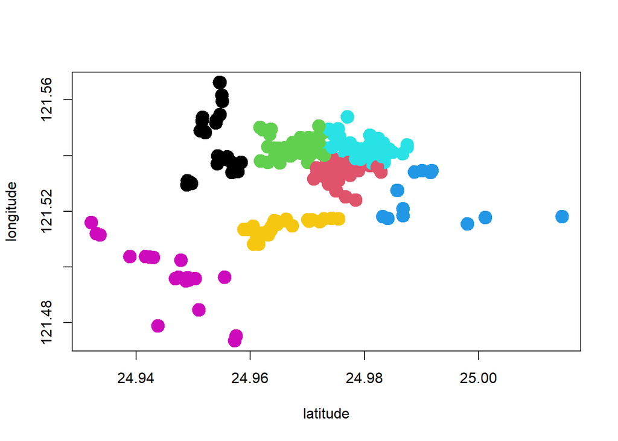

```r
clusters = kmeans(realEstate_data[,1:2], 7)

### Assign Labels
realEstate_data$Cluster = clusters$cluster

### Plot Clusters
plot(realEstate_data[,1:2],
     col = clusters$cluster,
     pch = 20, cex = 3)
```

## Regression

In this parts, I find a model in which one can predict the price per unit area of the real estate based on information about the real estate. The supported models are linear and logarithmic regression. Linear regression:
$$y_{i} = \alpha + \beta.x_{i}$$
Logarithmic regression:
$$y_{i} = \alpha + \beta.ln(x_{i})$$

To evaluate the model, the $R^{2}$ value is used which can be calculated based on the predicted residual sum of squares (PRESS) and total sum of squares (SST) described in the following formulas. The closer the $R^{2}$ value is to one, the better the model behaves.
$$SST = \sum_{i=1}^{n} (y^{ref}_{i}-y^{mean}_{i})^{2}$$
$$PRESS = \sum_{i=1}^{n} (y^{ref}_{i}-y^{pred}_{i})^{2}$$
$$R^{2} = 1 - \frac{PRESS}{SST}$$

### With the distance to the nearest MRT station

In the first part, I find a regression model between the price per unit area and the distance from the real estate to the nearest MRT station.

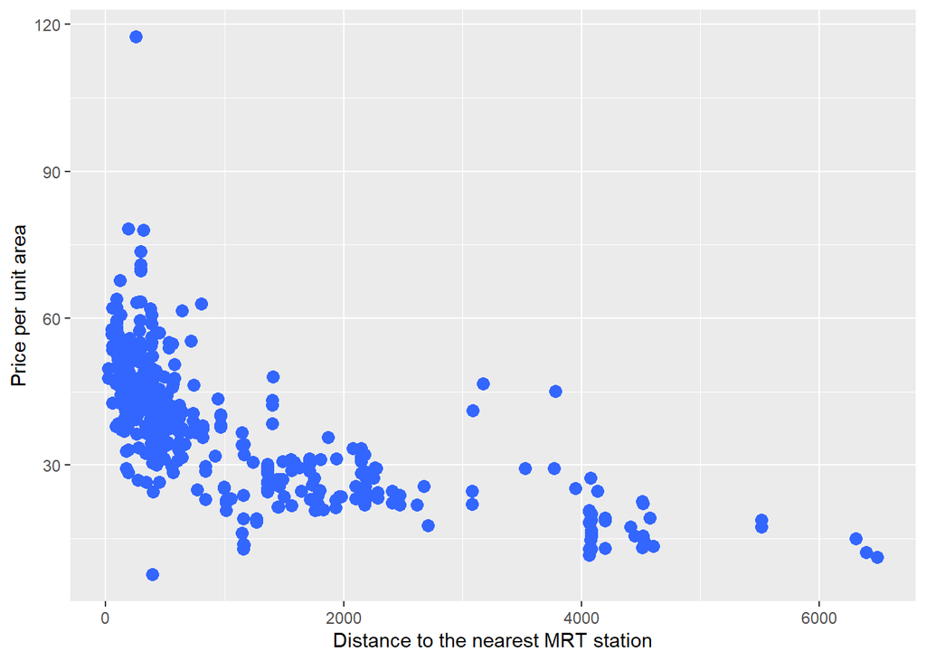

```r
## calc. the correlation between closest MRT station and price
realEstate$lnMRTDist <- log(realEstate$MRTDist)
realEstate$lnMRTDist[which(realEstate$lnMRTDist==-Inf)] = NA

p0 = qplot(MRTDist, unitPrice, data=realEstate, xlab="Distance to the nearest MRT station", ylab="Price per unit area") + geom_point(colour = "#3366FF", size = 3)
p0
```

```r
print(paste0("Correlation coefficient between price per unit area and dist. to the nearest MRT station: ", cor(realEstate$MRTDist, realEstate$unitPrice)))
```

```
## [1] "Correlation coefficient between price per unit area and dist. to the nearest MRT station: -0.673612855368918"
```

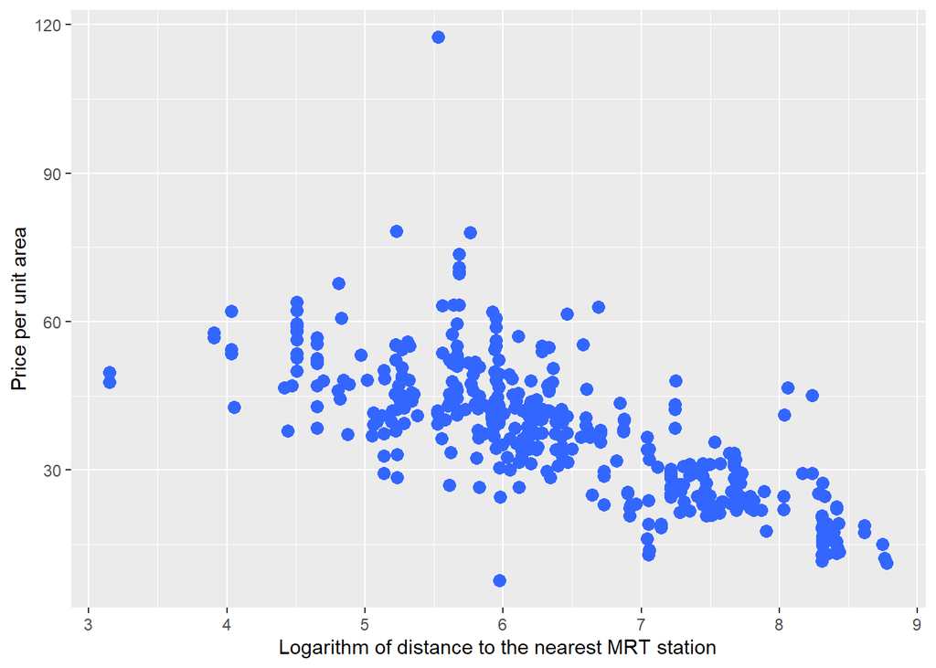

```r
p1 = qplot(lnMRTDist, unitPrice, data=realEstate, xlab="Logarithm of distance to the nearest MRT station", ylab="Price per unit area") + geom_point(colour = "#3366FF", size = 3)
p1
```

```r
print(paste0("Correlation coefficient between price per unit area and logarithm of dist. to the nearest MRT station: ", cor(realEstate$lnMRTDist, realEstate$unitPrice)))
```

```
## [1] "Correlation coefficient between price per unit area and logarithm of dist. to the nearest MRT station: -0.734338640591488"
```

```r
## the logarithm of dist. has a higher correlation therefore I pick the logarithm for the model

## fit the model
fit.lnMRTDist <- lm(formula = unitPrice ~ lnMRTDist, data = realEstate, na.action = na.exclude)
summary(fit.lnMRTDist)
```

```
##
## Call:
## lm(formula = unitPrice ~ lnMRTDist, data = realEstate, na.action = na.exclude)
##
## Residuals:
##     Min      1Q  Median      3Q     Max
## -34.103  -5.023  -0.827   3.449  71.846
##
## Coefficients:
##             Estimate Std. Error t value Pr(>|t|)
## (Intercept)  95.0169     2.6369   36.03   <2e-16 ***
## lnMRTDist    -8.9235     0.4064  -21.96   <2e-16 ***
## ---
## Signif. codes:  0 '***' 0.001 '**' 0.01 '*' 0.05 '.' 0.1 ' ' 1
##
## Residual standard error: 9.247 on 412 degrees of freedom
## Multiple R-squared:  0.5393, Adjusted R-squared:  0.5381
## F-statistic: 482.2 on 1 and 412 DF,  p-value: < 2.2e-16
```

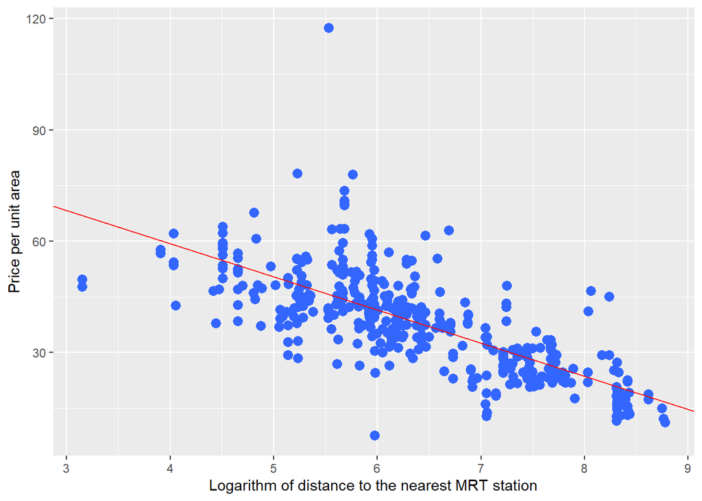

```r
## plot the model
p2 = p1 + geom_abline(intercept = fit.lnMRTDist[1]$coefficients[1], slope = fit.lnMRTDist[1]$coefficients[2], color="red")
p2
```

```r
## run and evaluate the model
## split the data to generate the train and test data sets:
set.seed(324)
splitPrice = caret::createDataPartition(realEstate$unitPrice, p = 0.8, list=F, times=1)
trainSet = realEstate[splitPrice,]
testSet = realEstate[-splitPrice,]
## train
lr = lm(unitPrice ~ lnMRTDist, data=trainSet)
lr
```

```
##
## Call:
## lm(formula = unitPrice ~ lnMRTDist, data = trainSet)
##
## Coefficients:
## (Intercept)    lnMRTDist
##      94.420       -8.794
```

```r
summary(lr)
```

```
##
## Call:
## lm(formula = unitPrice ~ lnMRTDist, data = trainSet)
##
## Residuals:
##     Min      1Q  Median      3Q     Max
## -19.947  -5.024  -1.113   3.203  71.728
##
## Coefficients:
##             Estimate Std. Error t value Pr(>|t|)
## (Intercept)  94.4200     2.8901   32.67   <2e-16 ***
## lnMRTDist    -8.7944     0.4445  -19.78   <2e-16 ***
## ---
## Signif. codes:  0 '***' 0.001 '**' 0.01 '*' 0.05 '.' 0.1 ' ' 1
##
## Residual standard error: 9.251 on 330 degrees of freedom
## Multiple R-squared:  0.5425, Adjusted R-squared:  0.5411
## F-statistic: 391.4 on 1 and 330 DF,  p-value: < 2.2e-16
```

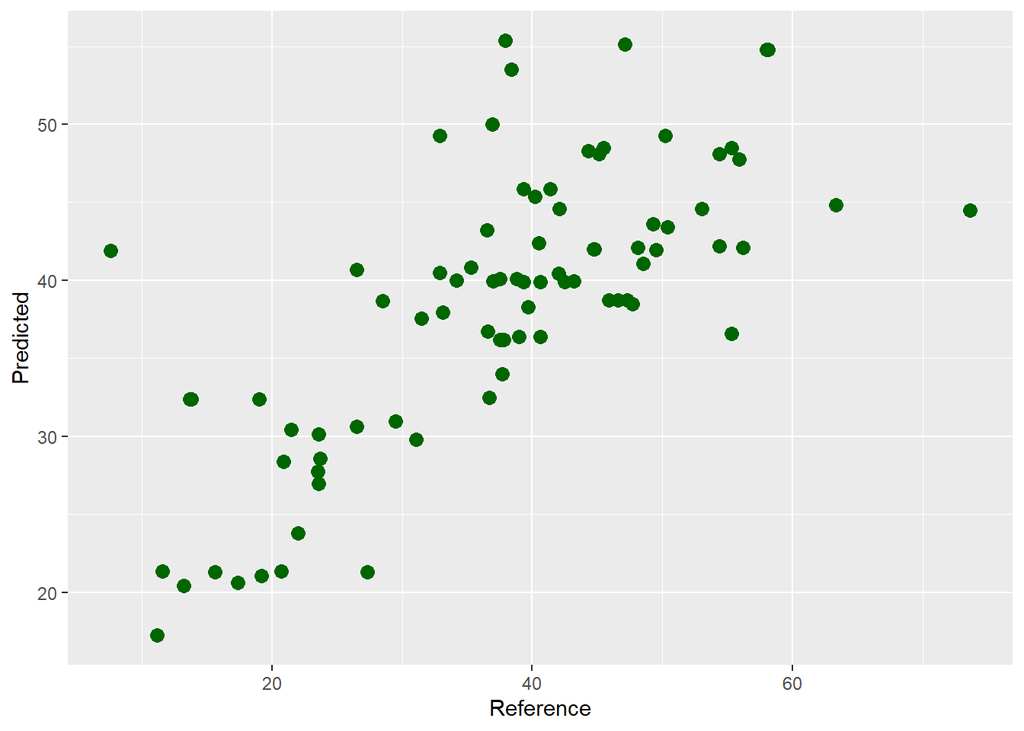

```r
## test:
predPrice = data.frame(predict(lr, newdata=testSet))
colnames(predPrice)[1] = 'Predicted'
predPrice$Reference = testSet[,c('unitPrice')]
predPrice$Predicted <- unlist(predPrice$Predicted)
predPrice$Reference <- unlist(predPrice$Reference)
p3 = qplot(Reference, Predicted, data=predPrice) + geom_point(colour = "#006600", size = 3)
p3
```

```r
## evaluation:
PRESS = sum((predPrice$Reference - predPrice$Predicted)^2)
SST = sum((predPrice$Reference - mean(predPrice$Reference))^2)
R2 = 1 - (PRESS/SST)
print(paste0("R2 = ", R2))
```

```
## [1] "R2 = 0.522175354193449"
```

### With the number of close convenience stores

In the second part, I find a regression model between the price per unit area and the number of convenience stores within walking distance to the real estate .

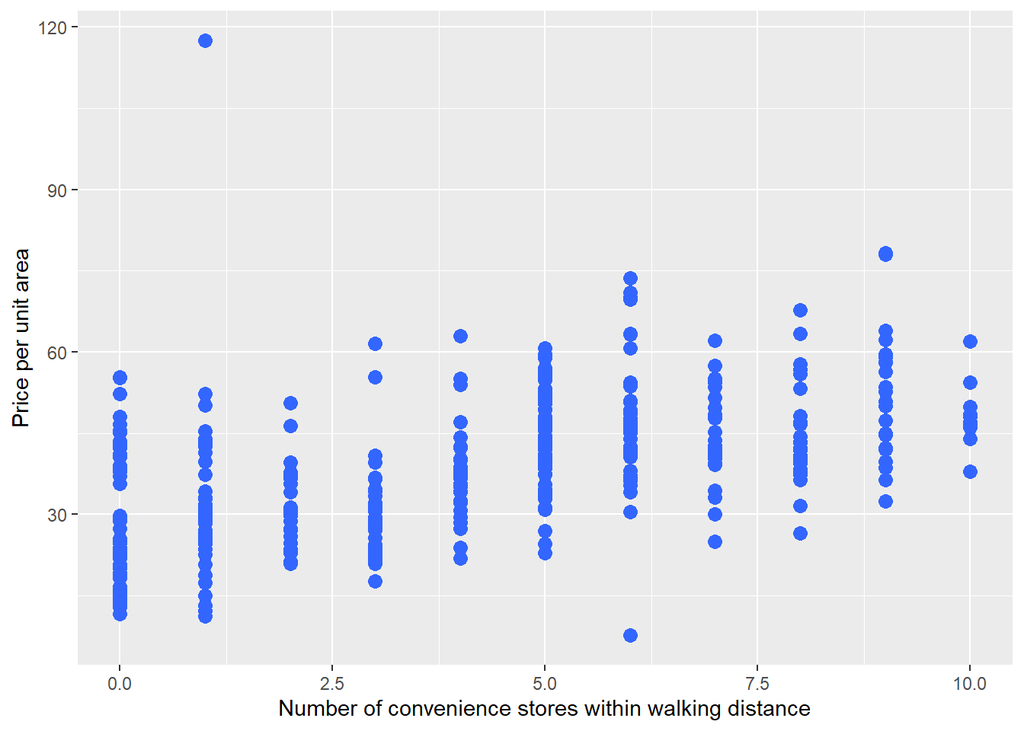

```r
## calc. the correlation between number of close stores and price
p0 = qplot(numStores, unitPrice, data=realEstate, xlab="Number of convenience stores within walking distance", ylab="Price per unit area") + geom_point(colour = "#3366FF", size = 3)
p0
```

```r
print(paste0("Correlation coefficient between price per unit area and number of convenience stores within walking distance: ", cor(realEstate$numStores, realEstate$unitPrice)))
```

```
## [1] "Correlation coefficient between price per unit area and number of convenience stores within walking distance: 0.571004911111148"
```

```r
## fit the model
fit.numStores <- lm(formula = unitPrice ~ numStores, data = realEstate, na.action = na.exclude)
summary(fit.numStores)
```

```
##
## Call:
## lm(formula = unitPrice ~ numStores, data = realEstate, na.action = na.exclude)
##
## Residuals:
##     Min      1Q  Median      3Q     Max
## -35.407  -7.341  -1.788   5.984  87.681
##
## Coefficients:
##             Estimate Std. Error t value Pr(>|t|)
## (Intercept)  27.1811     0.9419   28.86   <2e-16 ***
## numStores     2.6377     0.1868   14.12   <2e-16 ***
## ---
## Signif. codes:  0 '***' 0.001 '**' 0.01 '*' 0.05 '.' 0.1 ' ' 1
##
## Residual standard error: 11.18 on 412 degrees of freedom
## Multiple R-squared:  0.326,  Adjusted R-squared:  0.3244
## F-statistic: 199.3 on 1 and 412 DF,  p-value: < 2.2e-16
```

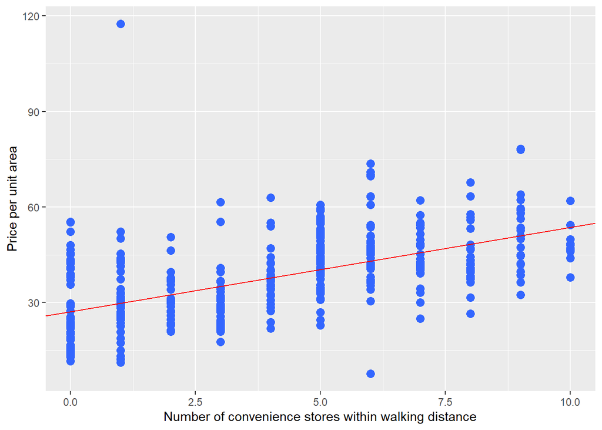

```r
p2 = p0 + geom_abline(intercept = fit.numStores[1]$coefficients[1], slope = fit.numStores[1]$coefficients[2], color="red")
p2
```

```r
## run and evaluate the model
## split the data to generate the train and test data sets:
set.seed(324)
splitPrice = caret::createDataPartition(realEstate$unitPrice, p = 0.8, list=F, times=1)
trainSet = realEstate[splitPrice,]
testSet = realEstate[-splitPrice,]
## train
lr = lm(unitPrice ~ numStores, data=trainSet)
lr
```

```
##
## Call:
## lm(formula = unitPrice ~ numStores, data = trainSet)
##
## Coefficients:
## (Intercept)    numStores
##      27.149        2.714
```

```r
summary(lr)
```

```
##
## Call:
## lm(formula = unitPrice ~ numStores, data = trainSet)
##
## Residuals:
##     Min      1Q  Median      3Q     Max
## -21.144  -7.273  -1.849   5.698  87.637
##
## Coefficients:
##             Estimate Std. Error t value Pr(>|t|)
## (Intercept)   27.149      1.059   25.64   <2e-16 ***
## numStores      2.713      0.213   12.74   <2e-16 ***
## ---
## Signif. codes:  0 '***' 0.001 '**' 0.01 '*' 0.05 '.' 0.1 ' ' 1
##
## Residual standard error: 11.2 on 330 degrees of freedom
## Multiple R-squared:  0.3296, Adjusted R-squared:  0.3275
## F-statistic: 162.2 on 1 and 330 DF,  p-value: < 2.2e-16
```

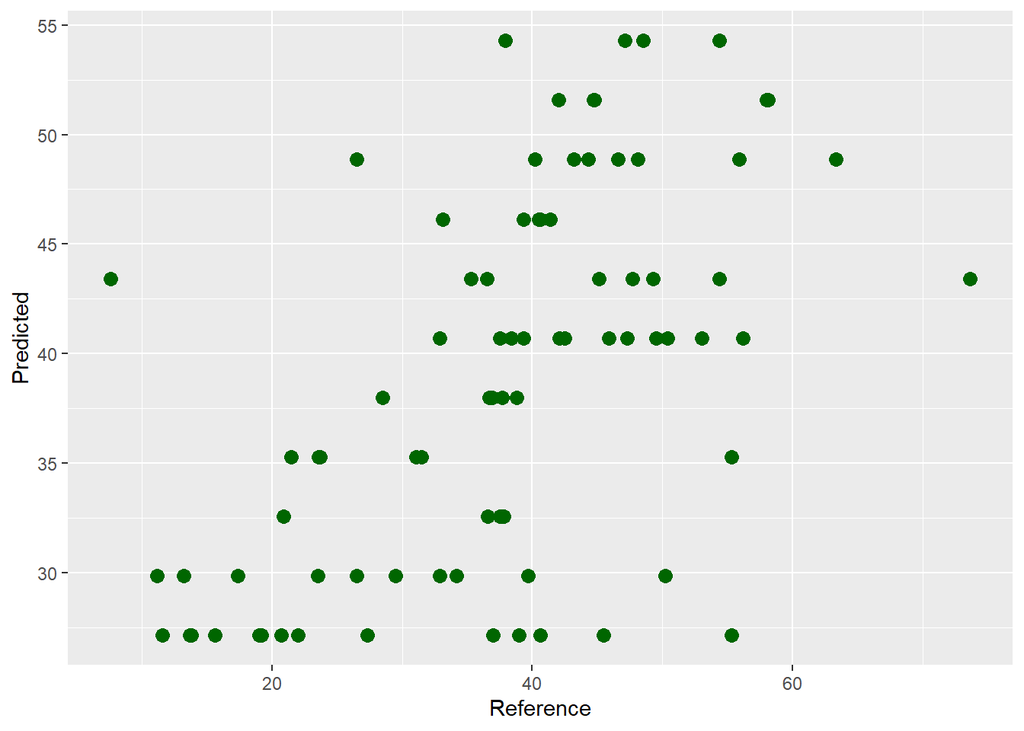

```r
## test:
predPrice = data.frame(predict(lr, newdata=testSet))
colnames(predPrice)[1] = 'Predicted'
predPrice$Reference = testSet[,c('unitPrice')]
predPrice$Predicted <- unlist(predPrice$Predicted)
predPrice$Reference <- unlist(predPrice$Reference)
p3 = qplot(Reference, Predicted, data=predPrice) + geom_point(colour = "#006600", size = 3)
p3
```

```r
## evaluation:
PRESS = sum((predPrice$Reference - predPrice$Predicted)^2)
SST = sum((predPrice$Reference - mean(predPrice$Reference))^2)
R2 = 1 - (PRESS/SST)
print(paste0("R2 = ", R2))
```

```
## [1] "R2 = 0.305805314558898"
```

### With the real estate age

In the third part, I find a regression model between the price per unit area and the age of the real estate .

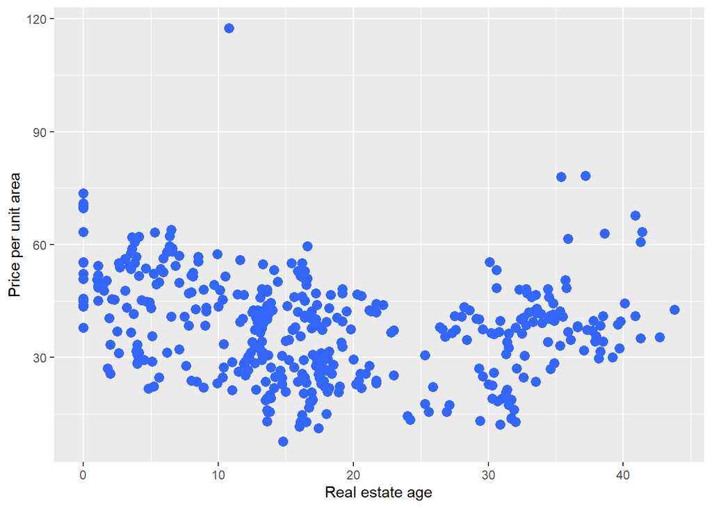

```r
## calc. the correlation
realEstate$lnAge <- log(realEstate$age)
realEstate$lnAge[which(realEstate$lnAge==-Inf)] = NA

p0 = qplot(age, unitPrice, data=realEstate, xlab="Real estate age", ylab="Price per unit area") + geom_point(colour = "#3366FF", size = 3)
p0
```

```r
print(paste0("Correlation coefficient between price per unit area and real estate age: ", cor(realEstate$age, realEstate$unitPrice, use="complete.obs")))
```

```
## [1] "Correlation coefficient between price per unit area and real estate age: -0.210567046277217"
```

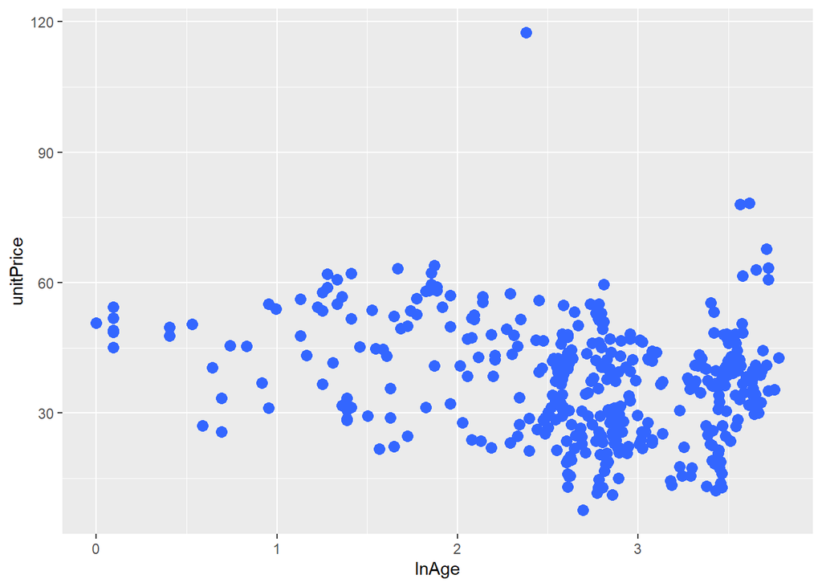

```r
p1 = qplot(lnAge, unitPrice, data=realEstate) + geom_point(colour = "#3366FF", size = 3)
p1
```

```r
print(paste0("Correlation coefficient between price per unit area and logarithm of real estate age: ", cor(realEstate$lnAge, realEstate$unitPrice, use="complete.obs")))
```

```
## [1] "Correlation coefficient between price per unit area and logarithm of real estate age: -0.244942199546067"
```

```r
## the logarithm has a higher correlation therefore I pick the logarithm for the model

## fit the model
fit.lnAge <- lm(formula = unitPrice ~ lnAge, data = realEstate, na.action = na.exclude)
summary(fit.lnAge)
```

```
##
## Call:
## lm(formula = unitPrice ~ lnAge, data = realEstate, na.action = na.exclude)
##
## Residuals:
##     Min      1Q  Median      3Q     Max
## -29.592 -10.267   1.491   8.208  79.026
##
## Coefficients:
##             Estimate Std. Error t value Pr(>|t|)
## (Intercept)  48.1504     2.2579  21.325  < 2e-16 ***
## lnAge        -4.0666     0.8099  -5.021 7.79e-07 ***
## ---
## Signif. codes:  0 '***' 0.001 '**' 0.01 '*' 0.05 '.' 0.1 ' ' 1
##
## Residual standard error: 12.89 on 395 degrees of freedom
##   (17 observations deleted due to missingness)
## Multiple R-squared:   0.06,  Adjusted R-squared:  0.05762
## F-statistic: 25.21 on 1 and 395 DF,  p-value: 7.792e-07
```

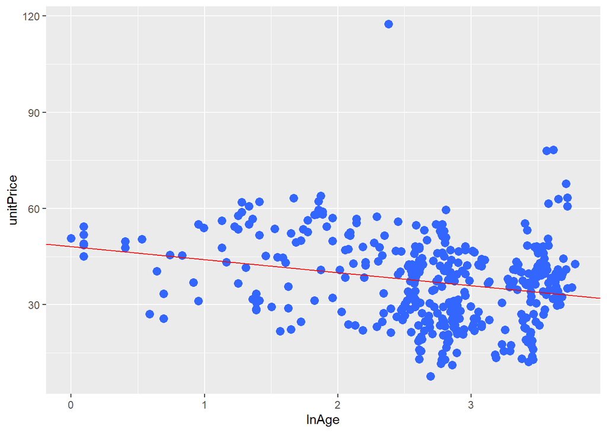

```r
## plot the model
p2 = p1 + geom_abline(intercept = fit.lnAge[1]$coefficients[1], slope = fit.lnAge[1]$coefficients[2], color="red")
p2
```

```r
## run and evaluate the model
## split the data to generate the train and test data sets:
set.seed(324)
splitPrice = caret::createDataPartition(realEstate$unitPrice, p = 0.8, list=F, times=1)
trainSet = realEstate[splitPrice,]
testSet = realEstate[-splitPrice,]
## train
lr = lm(unitPrice ~ lnAge, data=trainSet)
lr
```

```
##
## Call:
## lm(formula = unitPrice ~ lnAge, data = trainSet)
##
## Coefficients:
## (Intercept)        lnAge
##      48.241       -4.023
```

```r
summary(lr)
```

```
##
## Call:
## lm(formula = unitPrice ~ lnAge, data = trainSet)
##
## Residuals:
##     Min      1Q  Median      3Q     Max
## -24.740 -10.583   1.302   8.202  78.832
##
## Coefficients:
##             Estimate Std. Error t value Pr(>|t|)
## (Intercept)  48.2407     2.6167  18.436  < 2e-16 ***
## lnAge        -4.0230     0.9382  -4.288  2.4e-05 ***
## ---
## Signif. codes:  0 '***' 0.001 '**' 0.01 '*' 0.05 '.' 0.1 ' ' 1
##
## Residual standard error: 13.03 on 316 degrees of freedom
##   (14 observations deleted due to missingness)
## Multiple R-squared:  0.05498,    Adjusted R-squared:  0.05199
## F-statistic: 18.39 on 1 and 316 DF,  p-value: 2.4e-05
```

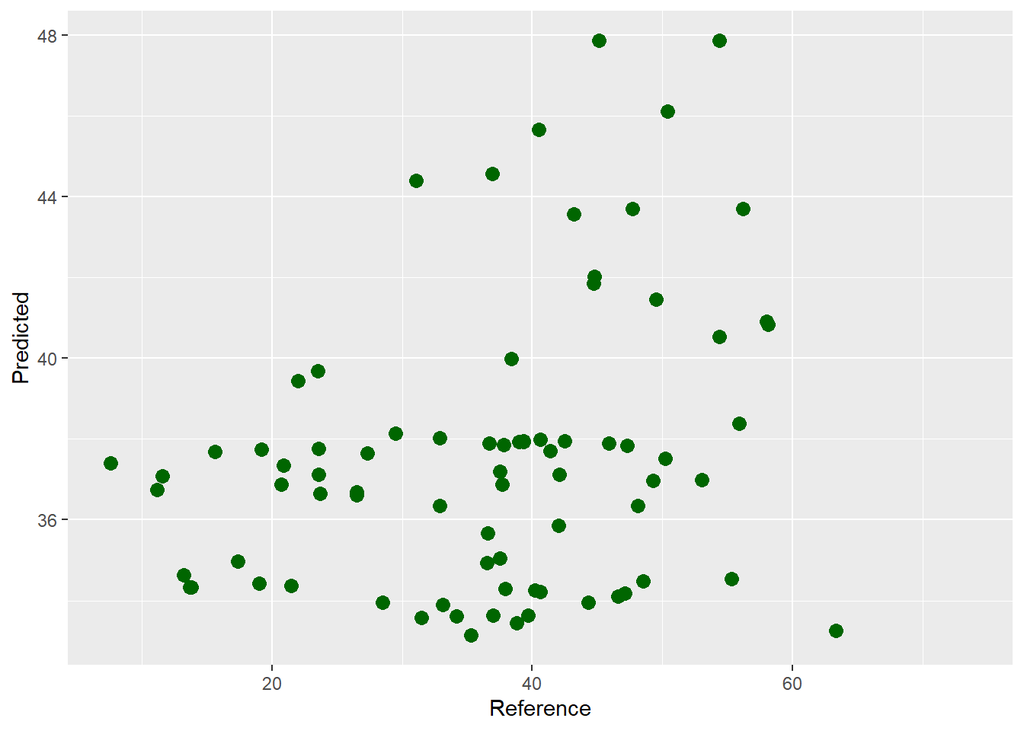

```r
## test:
predPrice = data.frame(predict(lr, newdata=testSet))
colnames(predPrice)[1] = 'Predicted'
predPrice$Reference = testSet[,c('unitPrice')]
predPrice$Predicted <- unlist(predPrice$Predicted)
predPrice$Reference <- unlist(predPrice$Reference)
p3 = qplot(Reference, Predicted, data=predPrice) + geom_point(colour = "#006600", size = 3)
p3
```

```r
## evaluation:
PRESS = sum((predPrice$Reference - predPrice$Predicted)^2, na.rm = TRUE)
SST = sum((predPrice$Reference - mean(predPrice$Reference))^2, na.rm = TRUE)
R2 = 1 - (PRESS/SST)
print(paste0("R2 = ", R2))
```

```
## [1] "R2 = 0.187002611089486"
```

### With the transaction date

In the fourth part, I find a regression model between the price per unit area and the transaction date of the real estate.

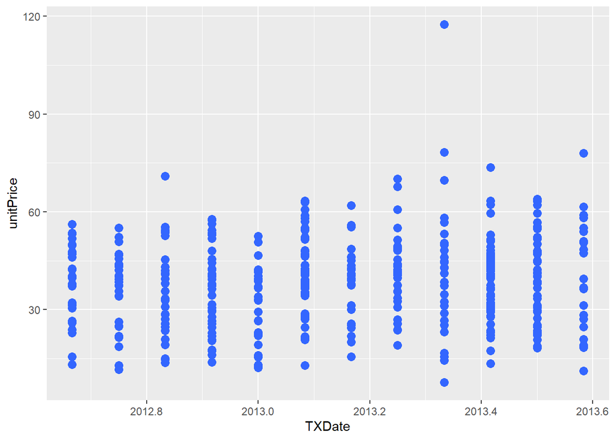

```r
## calc. the correlation
p0 = qplot(TXDate, unitPrice, data=realEstate) + geom_point(colour = "#3366FF", size = 3)
p0
```

```r
print(paste0("Correlation coefficient between price per unit area and transaction date: ", cor(realEstate$TXDate, realEstate$unitPrice, use="complete.obs")))
```

```
## [1] "Correlation coefficient between price per unit area and transaction date: 0.0875292716972599"
```

```r
## fit the model
fit.TXDate <- lm(formula = unitPrice ~ TXDate, data = realEstate, na.action = na.exclude)
summary(fit.TXDate)
```

```
##
## Call:
## lm(formula = unitPrice ~ TXDate, data = realEstate, na.action = na.exclude)
##
## Residuals:
##     Min      1Q  Median      3Q     Max
## -31.159 -10.082   0.923   8.528  78.741
##
## Coefficients:
##              Estimate Std. Error t value Pr(>|t|)
## (Intercept) -8464.260   4767.178  -1.776   0.0765 .
## TXDate          4.223      2.368   1.783   0.0752 .
## ---
## Signif. codes:  0 '***' 0.001 '**' 0.01 '*' 0.05 '.' 0.1 ' ' 1
##
## Residual standard error: 13.57 on 412 degrees of freedom
## Multiple R-squared:  0.007661,   Adjusted R-squared:  0.005253
## F-statistic: 3.181 on 1 and 412 DF,  p-value: 0.07524
```

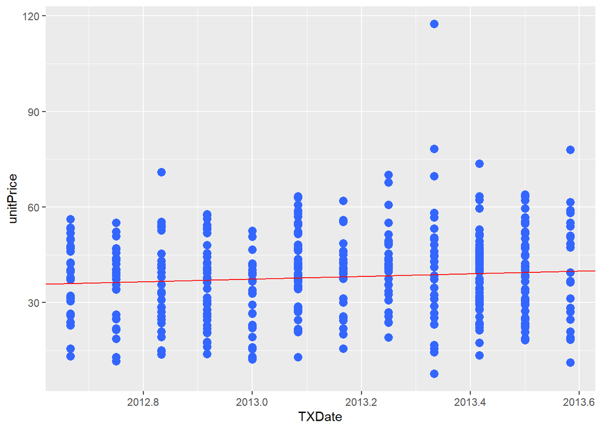

```r
## plot the model
p2 = p0 + geom_abline(intercept = fit.TXDate[1]$coefficients[1], slope = fit.TXDate[1]$coefficients[2], color="red")
p2
```

```r
## run and evaluate the model
## split the data to generate the train and test data sets:
set.seed(324)
splitPrice = caret::createDataPartition(realEstate$unitPrice, p = 0.8, list=F, times=1)
trainSet = realEstate[splitPrice,]
testSet = realEstate[-splitPrice,]
## train
lr = lm(unitPrice ~ TXDate, data=trainSet)
lr
```

```
##
## Call:
## lm(formula = unitPrice ~ TXDate, data = trainSet)
##
## Coefficients:
## (Intercept)       TXDate
##   -8352.272        4.168
```

```r
summary(lr)
```

```
##
## Call:
## lm(formula = unitPrice ~ TXDate, data = trainSet)
##
## Residuals:
##     Min      1Q  Median      3Q     Max
## -25.816 -10.202   0.637   8.437  78.632
##
## Coefficients:
##              Estimate Std. Error t value Pr(>|t|)
## (Intercept) -8352.272   5344.754  -1.563    0.119
## TXDate          4.168      2.655   1.570    0.117
##
## Residual standard error: 13.63 on 330 degrees of freedom
## Multiple R-squared:  0.007413,   Adjusted R-squared:  0.004405
## F-statistic: 2.464 on 1 and 330 DF,  p-value: 0.1174
```

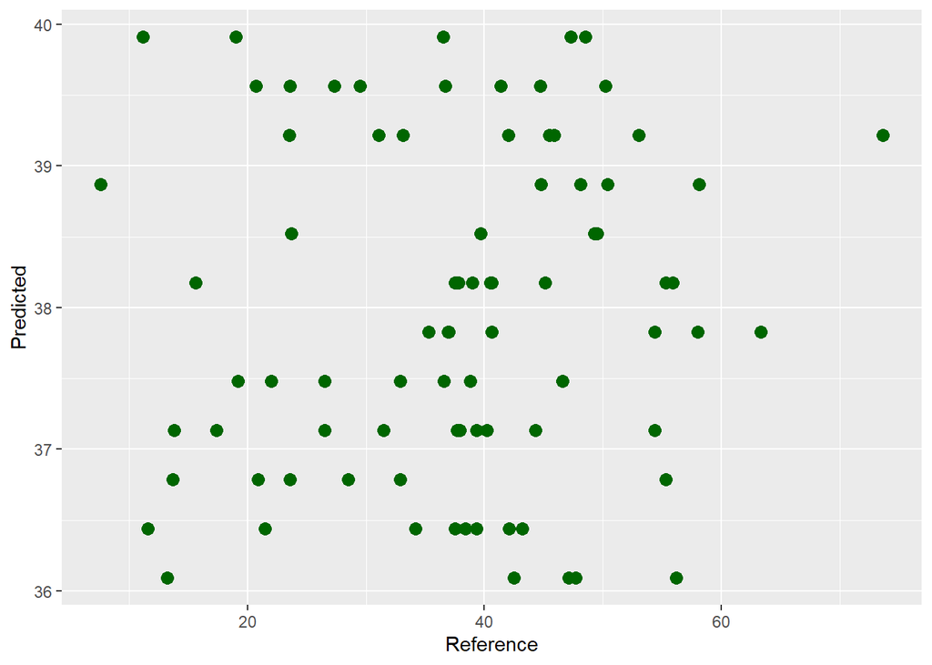

```r
## test:
predPrice = data.frame(predict(lr, newdata=testSet))
colnames(predPrice)[1] = 'Predicted'
predPrice$Reference = testSet[,c('unitPrice')]
predPrice$Predicted <- unlist(predPrice$Predicted)
predPrice$Reference <- unlist(predPrice$Reference)
p3 = qplot(Reference, Predicted, data=predPrice) + geom_point(colour = "#006600", size = 3)
p3
```

```r
## evaluation:
PRESS = sum((predPrice$Reference - predPrice$Predicted)^2, na.rm = TRUE)
SST = sum((predPrice$Reference - mean(predPrice$Reference))^2, na.rm = TRUE)
R2 = 1 - (PRESS/SST)
print(paste0("R2 = ", R2))
```

```
## [1] "R2 = 0.00561554161692146"
```

### With geographical coordinates

In the fourth part, I find a regression model between the price per unit area and the geographical coordinates of the real estate.

```r
## calc. the x and y coordinates based on longitude and latitude
realEstate$xcoord <- latlong2grid(cbind(realEstate$longitude,realEstate$latitude))$x
realEstate$ycoord <- latlong2grid(cbind(realEstate$longitude,realEstate$latitude))$y
realEstate$rcoord <- sqrt(realEstate$xcoord^2 + realEstate$ycoord^2)

## run and evaluate the model
## split the data to generate the train and test data sets:
set.seed(324)
splitPrice = caret::createDataPartition(realEstate$unitPrice, p = 0.8, list=F, times=1)
trainSet = realEstate[splitPrice,]
testSet = realEstate[-splitPrice,]
## train
lr = lm(unitPrice ~ xcoord + ycoord, data=trainSet)
lr
```

```
##
## Call:
## lm(formula = unitPrice ~ xcoord + ycoord, data = trainSet)
##
## Coefficients:
## (Intercept)       xcoord       ycoord
##  -48696.155        3.598        3.856
```

```r
summary(lr)
```

```
##
## Call:
## lm(formula = unitPrice ~ xcoord + ycoord, data = trainSet)
##
## Residuals:
##     Min      1Q  Median      3Q     Max
## -24.975  -6.511  -1.085   4.339  77.646
##
## Coefficients:
##               Estimate Std. Error t value Pr(>|t|)
## (Intercept) -4.870e+04  4.697e+03 -10.367  < 2e-16 ***
## xcoord       3.598e+00  4.824e-01   7.460 7.78e-13 ***
## ycoord       3.856e+00  4.756e-01   8.107 1.03e-14 ***
## ---
## Signif. codes:  0 '***' 0.001 '**' 0.01 '*' 0.05 '.' 0.1 ' ' 1
##
## Residual standard error: 10.71 on 329 degrees of freedom
## Multiple R-squared:  0.3892, Adjusted R-squared:  0.3855
## F-statistic: 104.8 on 2 and 329 DF,  p-value: < 2.2e-16
```

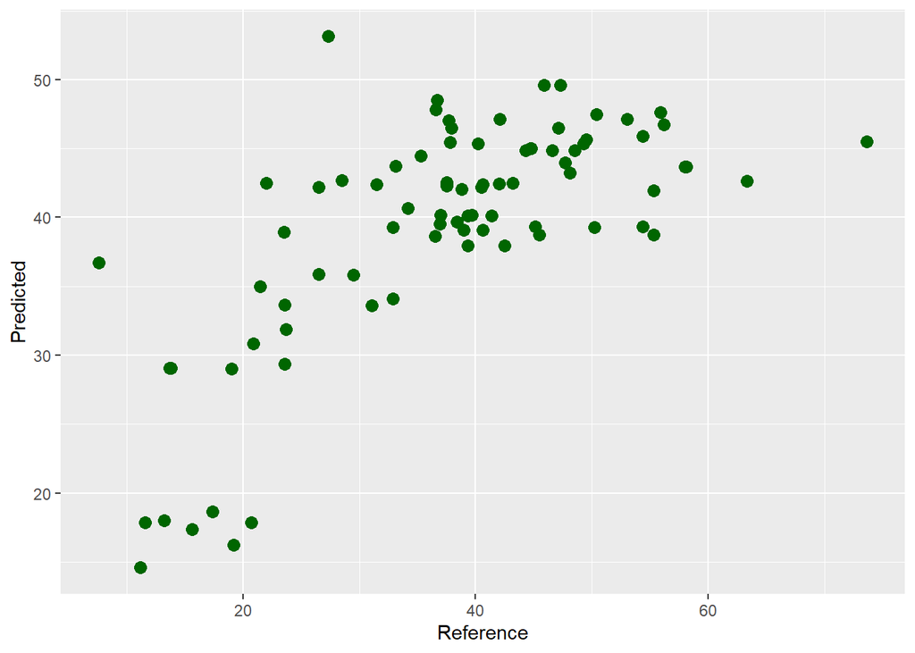

```r
## test:
predPrice = data.frame(predict(lr, newdata=testSet))
colnames(predPrice)[1] = 'Predicted'
predPrice$Reference = testSet[,c('unitPrice')]
predPrice$Predicted <- unlist(predPrice$Predicted)
predPrice$Reference <- unlist(predPrice$Reference)
p3 = qplot(Reference, Predicted, data=predPrice) + geom_point(colour = "#006600", size = 3)
p3
```

```r
## evaluation:
PRESS = sum((predPrice$Reference - predPrice$Predicted)^2)
SST = sum((predPrice$Reference - mean(predPrice$Reference))^2)
R2 = 1 - (PRESS/SST)
print(paste0("R2 = ", R2))
```

```
## [1] "R2 = 0.466247956664736"
```

### Multi-variable regression

Finally, I find a regression model based on all of the independent variables evaluated in the previous parts.

```r
## split the data to generate the train and test data sets:
set.seed(324)
splitPrice = caret::createDataPartition(realEstate$unitPrice, p = 0.8, list=F, times=1)
trainSet = realEstate[splitPrice,]
testSet = realEstate[-splitPrice,]


## train
lr = lm(unitPrice ~ lnMRTDist + numStores + lnAge + TXDate + xcoord + ycoord, data=trainSet)
lr
```

```
##
## Call:
## lm(formula = unitPrice ~ lnMRTDist + numStores + lnAge + TXDate +
##     xcoord + ycoord, data = trainSet)
##
## Coefficients:
## (Intercept)    lnMRTDist    numStores        lnAge       TXDate       xcoord
##  -2.193e+04   -6.589e+00    2.815e-01   -2.996e+00    7.492e+00    6.369e-03
##      ycoord
##   2.473e+00
```

```r
summary(lr)
```

```
##
## Call:
## lm(formula = unitPrice ~ lnMRTDist + numStores + lnAge + TXDate +
##     xcoord + ycoord, data = trainSet)
##
## Residuals:
##     Min      1Q  Median      3Q     Max
## -19.487  -4.233  -0.581   3.137  71.095
##
## Coefficients:
##               Estimate Std. Error t value Pr(>|t|)
## (Intercept) -2.193e+04  5.581e+03  -3.929 0.000105 ***
## lnMRTDist   -6.589e+00  6.941e-01  -9.493  < 2e-16 ***
## numStores    2.815e-01  2.374e-01   1.186 0.236555
## lnAge       -2.996e+00  5.837e-01  -5.133 5.04e-07 ***
## TXDate       7.492e+00  1.603e+00   4.673 4.43e-06 ***
## xcoord       6.369e-03  4.439e-01   0.014 0.988562
## ycoord       2.473e+00  3.824e-01   6.468 3.86e-10 ***
## ---
## Signif. codes:  0 '***' 0.001 '**' 0.01 '*' 0.05 '.' 0.1 ' ' 1
##
## Residual standard error: 7.948 on 311 degrees of freedom
##   (14 observations deleted due to missingness)
## Multiple R-squared:  0.6541, Adjusted R-squared:  0.6474
## F-statistic:    98 on 6 and 311 DF,  p-value: < 2.2e-16
```

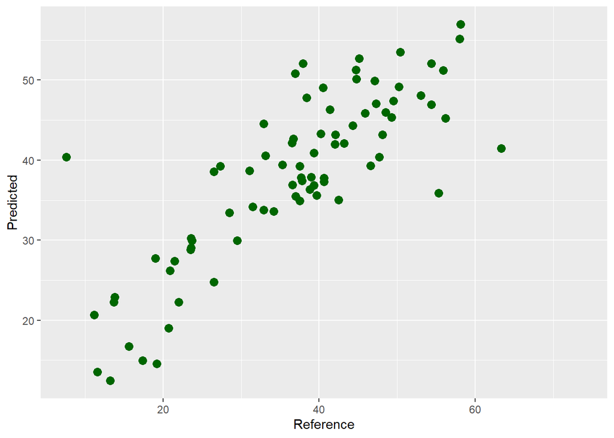

```r
## test:
predPrice = data.frame(predict(lr, newdata=testSet))
colnames(predPrice)[1] = 'Predicted'
predPrice$Reference = testSet[,c('unitPrice')]
predPrice$Predicted <- unlist(predPrice$Predicted)
predPrice$Reference <- unlist(predPrice$Reference)
p3 = qplot(Reference, Predicted, data=predPrice) + geom_point(colour = "#006600", size = 3)
p3
```

```r
## evaluation:
PRESS = sum((predPrice$Reference - predPrice$Predicted)^2, na.rm = TRUE)
SST = sum((predPrice$Reference - mean(predPrice$Reference))^2, na.rm = TRUE)
R2 = 1 - (PRESS/SST)
print(paste0("R2 = ", R2))
```

```
## [1] "R2 = 0.700259705732369"
```

### Conclusion

There is a significant improvement in the multi-variable regression model compared to the single-variable ones. The $R^2$ for the multi-varialbe is around 0.7 whereas the maximum number for $R^2$ in single-variable models was 0.52 (belonging to the logarithm of the closest MRT station distance).